# Starbucks Capstone Challenge

## Working on Portfolio Dataset to clean and understand more

#### This is the easy dataset to deal, as it's includes 10 records with 6 columns

```python
def clean_portfolioDataset(portfolio):
    '''
    The below code will clean the portfolio dataset which includes the id (string) - offer id
    offer_type (string) - type of offer ie BOGO, discount, informational
    difficulty (int) - minimum required spend to complete an offer
    reward (int) - reward given for completing an offer
    duration (int) - time for offer to be open, in days
    channels (list of strings)

    OUTPUT:
    portfolio - the cleaned portfolio dataframe

    '''
    # Convert the duration from day to hours to be matched in the transcript dataset.
    cleaned_portfolio = portfolio.copy()
    cleaned_portfolio['duration'] = cleaned_portfolio['duration'] * 24

    # apply one hot encoding to channels column from Term 1
    cleaned_portfolio['web'] = cleaned_portfolio['channels'].apply(lambda x: 1 if 'web' in x else 0)
    cleaned_portfolio['email'] = cleaned_portfolio['channels'].apply(lambda x: 1 if 'email' in x else 0)
    cleaned_portfolio['mobile'] = cleaned_portfolio['channels'].apply(lambda x: 1 if 'mobile' in x else 0)
    cleaned_portfolio['social'] = cleaned_portfolio['channels'].apply(lambda x: 1 if 'social' in x else 0)

    # apply one hot encoding to offer_type column
    offer_type = pd.get_dummies(cleaned_portfolio['offer_type'])

    # drop the channels and offer_type column as we already hot encoding them into a different shape
    cleaned_portfolio.drop(['channels', 'offer_type'], axis=1, inplace=True)

    # combine the portfolio and offer_type dataframe to form a cleaned dataframe
    cleaned_portfolio = pd.concat([cleaned_portfolio, offer_type], axis=1, sort=False)

    return cleaned_portfolio
```

```python
cleaned_portfolio = clean_portfolioDataset(portfolio)
```

```python
cleaned_portfolio.shape
```

```
(10, 11)
```

```python
cleaned_portfolio.head(10)
```

|  | difficulty | duration | id | reward | web | email | mobile | social | bogo | discount | informational |
| --- | --- | --- | --- | --- | --- | --- | --- | --- | --- | --- | --- |
| 0 | 10 | 168 | ae264e3637204a6fb9bb56bc8210ddfd | 10 | 0 | 1 | 1 | 1 | 1 | 0 | 0 |
| 1 | 10 | 120 | 4d5c57ea9a6940dd891ad53e9dbe8da0 | 10 | 1 | 1 | 1 | 1 | 1 | 0 | 0 |
| 2 | 0 | 96 | 3f207df678b143eea3cee63160fa8bed | 0 | 1 | 1 | 1 | 0 | 0 | 0 | 1 |
| 3 | 5 | 168 | 9b98b8c7a33c4b65b9aebfe6a799e6d9 | 5 | 1 | 1 | 1 | 0 | 1 | 0 | 0 |
| 4 | 20 | 240 | 0b1e1539f2cc45b7b9fa7c272da2e1d7 | 5 | 1 | 1 | 0 | 0 | 0 | 1 | 0 |
| 5 | 7 | 168 | 2298d6c36e964ae4a3e7e9706d1fb8c2 | 3 | 1 | 1 | 1 | 1 | 0 | 1 | 0 |
| 6 | 10 | 240 | fafdcd668e3743c1bb461111dcafc2a4 | 2 | 1 | 1 | 1 | 1 | 0 | 1 | 0 |
| 7 | 0 | 72 | 5a8bc65990b245e5a138643cd4eb9837 | 0 | 0 | 1 | 1 | 1 | 0 | 0 | 1 |
| 8 | 5 | 120 | f19421c1d4aa40978ebb69ca19b0e20d | 5 | 1 | 1 | 1 | 1 | 1 | 0 | 0 |
| 9 | 10 | 168 | 2906b810c7d4411798c6938adc9daaa5 | 2 | 1 | 1 | 1 | 0 | 0 | 1 | 0 |

Now, I need to deal with profile dataset and check whats the works need to be done in it.

```python
profile.shape
```

```
(17000, 5)
```

```python
profile.head(30)
```

|  | age | became_member_on | gender | id | income |
| --- | --- | --- | --- | --- | --- |
| 0 | 118 | 20170212 | None | 68be06ca386d4c31939f3a4f0e3dd783 | NaN |
| 1 | 55 | 20170715 | F | 0610b486422d4921ae7d2bf64640c50b | 112000.0 |
| 2 | 118 | 20180712 | None | 38fe809add3b4fcf9315a9694bb96ff5 | NaN |
| 3 | 75 | 20170509 | F | 78afa995795e4d85b5d9ceeca43f5fef | 100000.0 |
| 4 | 118 | 20170804 | None | a03223e636434f42ac4c3df47e8bac43 | NaN |
| 5 | 68 | 20180426 | M | e2127556f4f64592b11af22de27a7932 | 70000.0 |
| 6 | 118 | 20170925 | None | 8ec6ce2a7e7949b1bf142def7d0e0586 | NaN |
| 7 | 118 | 20171002 | None | 68617ca6246f4fbc85e91a2a49552598 | NaN |
| 8 | 65 | 20180209 | M | 389bc3fa690240e798340f5a15918d5c | 53000.0 |
| 9 | 118 | 20161122 | None | 8974fc5686fe429db53ddde067b88302 | NaN |
| 10 | 118 | 20170824 | None | c4863c7985cf408faee930f111475da3 | NaN |
| 11 | 118 | 20150919 | None | 148adfcaa27d485b82f323aaaad036bd | NaN |
| 12 | 58 | 20171111 | M | 2eeac8d8feae4a8cad5a6af0499a211d | 51000.0 |
| 13 | 61 | 20170911 | F | aa4862eba776480b8bb9c68455b8c2e1 | 57000.0 |
| 14 | 26 | 20140213 | M | e12aeaf2d47d42479ea1c4ac3d8286c6 | 46000.0 |
| 15 | 62 | 20160211 | F | 31dda685af34476cad5bc968bdb01c53 | 71000.0 |
| 16 | 49 | 20141113 | M | 62cf5e10845442329191fc246e7bcea3 | 52000.0 |
| 17 | 118 | 20170801 | None | 744d603ef08c4f33af5a61c8c7628d1c | NaN |
| 18 | 57 | 20171231 | M | 6445de3b47274c759400cd68131d91b4 | 42000.0 |
| 19 | 61 | 20180501 | F | a448667f336b42c9a66fc5ffd5d73772 | 40000.0 |
| 20 | 40 | 20160504 | F | 440cf1fd7580490c971d8c651ed962af | 71000.0 |
| 21 | 64 | 20170909 | M | 4b0da7e80e5945209a1fdddfe813dbe0 | 100000.0 |
| 22 | 78 | 20170616 | F | c27e0d6ab72c455a8bb66d980963de60 | 71000.0 |
| 23 | 118 | 20170907 | None | 2b826eba31074a059d63b0ae8f50b7d5 | NaN |
| 24 | 42 | 20130811 | M | f806632c011441378d4646567f357a21 | 69000.0 |
| 25 | 56 | 20180428 | F | d058f73bf8674a26a95227db098147b1 | 88000.0 |
| 26 | 118 | 20170330 | None | 65aba5c617294649aeb624da249e1ee5 | NaN |
| 27 | 33 | 20170926 | F | c6c9884912c645429f3333f912b55f44 | 52000.0 |
| 28 | 46 | 20170911 | F | 7429a044884842d6862f516c38b1156f | 59000.0 |
| 29 | 59 | 20150121 | M | ebe7ef46ea6f4963a7dd49f501b26779 | 41000.0 |

Gender and Income includes null values, in addition, the age in some of the records is high and those elederly persons it will be difficult to go to starbucks to drink coffee, so I will exclude anyrecord more than 100 (age value)

```python
def cleanprofiledataset(profile):
    cleaned_profile = profile.copy()
    profile['age'] = profile['age'].apply(lambda x: np.nan if x > 100 else x)

    # drop all missing values in all the dataset which includes 17000 records
    profile.dropna(inplace=True)

    return profile
```

```python
cleanprofiledataset(profile)
```

|  | age | became_member_on | gender | id | income |
| --- | --- | --- | --- | --- | --- |
| 1 | 55.0 | 20170715 | F | 0610b486422d4921ae7d2bf64640c50b | 112000.0 |
| 3 | 75.0 | 20170509 | F | 78afa995795e4d85b5d9ceeca43f5fef | 100000.0 |
| 5 | 68.0 | 20180426 | M | e2127556f4f64592b11af22de27a7932 | 70000.0 |
| 8 | 65.0 | 20180209 | M | 389bc3fa690240e798340f5a15918d5c | 53000.0 |
| 12 | 58.0 | 20171111 | M | 2eeac8d8feae4a8cad5a6af0499a211d | 51000.0 |
| 13 | 61.0 | 20170911 | F | aa4862eba776480b8bb9c68455b8c2e1 | 57000.0 |
| 14 | 26.0 | 20140213 | M | e12aeaf2d47d42479ea1c4ac3d8286c6 | 46000.0 |
| 15 | 62.0 | 20160211 | F | 31dda685af34476cad5bc968bdb01c53 | 71000.0 |
| 16 | 49.0 | 20141113 | M | 62cf5e10845442329191fc246e7bcea3 | 52000.0 |
| 18 | 57.0 | 20171231 | M | 6445de3b47274c759400cd68131d91b4 | 42000.0 |
| 19 | 61.0 | 20180501 | F | a448667f336b42c9a66fc5ffd5d73772 | 40000.0 |
| 20 | 40.0 | 20160504 | F | 440cf1fd7580490c971d8c651ed962af | 71000.0 |
| 21 | 64.0 | 20170909 | M | 4b0da7e80e5945209a1fdddfe813dbe0 | 100000.0 |
| 22 | 78.0 | 20170616 | F | c27e0d6ab72c455a8bb66d980963de60 | 71000.0 |
| 24 | 42.0 | 20130811 | M | f806632c011441378d4646567f357a21 | 69000.0 |
| 25 | 56.0 | 20180428 | F | d058f73bf8674a26a95227db098147b1 | 88000.0 |
| 27 | 33.0 | 20170926 | F | c6c9884912c645429f3333f912b55f44 | 52000.0 |
| 28 | 46.0 | 20170911 | F | 7429a044884842d6862f516c38b1156f | 59000.0 |
| 29 | 59.0 | 20150121 | M | ebe7ef46ea6f4963a7dd49f501b26779 | 41000.0 |
| 30 | 67.0 | 20140823 | M | 5917d13f6fa04286abdf95f4d5cefb1e | 96000.0 |
| 31 | 53.0 | 20170916 | O | d1ede868e29245ea91818a903fec04c6 | 52000.0 |
| 32 | 22.0 | 20170925 | M | 1e9420836d554513ab90eba98552d0a9 | 70000.0 |
| 33 | 96.0 | 20171117 | F | 868317b9be554cb18e50bc68484749a2 | 89000.0 |
| 34 | 40.0 | 20160709 | M | f082d80f0aac47a99173ba8ef8fc1909 | 33000.0 |
| 35 | 69.0 | 20160814 | F | 102e9454054946fda62242d2e176fdce | 57000.0 |
| 37 | 56.0 | 20140511 | M | 8dabe2142cdf4013a6f4786edf8ab00f | 68000.0 |
| 38 | 26.0 | 20170812 | F | 9f30b375d7bd4c62a884ffe7034e09ee | 63000.0 |
| 40 | 75.0 | 20151112 | M | 6e014185620b49bd98749f728747572f | 40000.0 |
| 41 | 20.0 | 20160711 | F | 02c083884c7d45b39cc68e1314fec56c | 30000.0 |
| 42 | 45.0 | 20180707 | M | c0d210398dee4a0895b24444a5fcd1d2 | 33000.0 |
| ... | ... | ... | ... | ... | ... |
| 16963 | 62.0 | 20170112 | F | 8c3fbf6b89b248bb99b7a6ca628f401c | 80000.0 |
| 16964 | 52.0 | 20180408 | M | 68213b08d99a4ae1b0dcb72aebd9aa35 | 62000.0 |
| 16965 | 52.0 | 20180409 | M | e340cbf00a914f0c958577c0af36ed8a | 34000.0 |
| 16966 | 54.0 | 20150126 | M | 10316535e185400fb093c371d62254e3 | 51000.0 |
| 16967 | 54.0 | 20150626 | M | cec1cdc6b77e41abbdce8903c5522e7e | 53000.0 |
| 16968 | 74.0 | 20170725 | M | 2c6f50c1c07a444896e2a4e31d724f92 | 87000.0 |
| 16970 | 67.0 | 20151107 | M | a2e6029e17b6466187a40b66e333a73e | 94000.0 |
| 16971 | 52.0 | 20180522 | F | 6e71b66784844d1ab8376ac8ab096d4b | 75000.0 |
| 16972 | 44.0 | 20170119 | F | e2fd53ed790240c586b3188f23542cca | 51000.0 |
| 16973 | 30.0 | 20151012 | M | 08eb126ad33f447ca3ad076482445c05 | 57000.0 |
| 16974 | 59.0 | 20160113 | F | f88e91a11d8f405b9a47ad3741415b83 | 71000.0 |
| 16975 | 61.0 | 20171231 | F | 1b4df4b48bf64727a4c445909aea1251 | 81000.0 |
| 16976 | 39.0 | 20160921 | F | 122c0c2a3c2540848f8c3fdc37e97639 | 54000.0 |
| 16978 | 29.0 | 20170220 | F | 54bead4179c44b71acc4e8398181d183 | 58000.0 |
| 16979 | 63.0 | 20130922 | F | a00058cf10334a308c68e7631c529907 | 52000.0 |
| 16981 | 84.0 | 20160629 | M | 1966fa40d2f84620b2b1b9b64f8e0209 | 93000.0 |
| 16983 | 72.0 | 20150404 | F | ff737c250d2343729ade04c4f6eb1001 | 65000.0 |
| 16984 | 75.0 | 20160716 | F | 392d23b2c958493197f647bedfe4f418 | 78000.0 |
| 16985 | 26.0 | 20180619 | M | 97ee6e7a12fe4064b260fa48bdd0330f | 55000.0 |
| 16986 | 59.0 | 20170731 | F | bf3069b178fe40d789dd027901bc406b | 63000.0 |
| 16987 | 57.0 | 20160709 | M | 76ddbd6576844afe811f1a3c0fbb5bec | 40000.0 |
| 16988 | 64.0 | 20180104 | M | f653cf2d8bba42d0a53c2937ee2e5893 | 51000.0 |
| 16990 | 70.0 | 20160310 | F | 79edb810789c447e8d212a324b44cc16 | 39000.0 |
| 16992 | 21.0 | 20170917 | F | 400d0536e8794cbb855b0d882d67cbda | 72000.0 |
| 16993 | 60.0 | 20180505 | M | cb23b66c56f64b109d673d5e56574529 | 113000.0 |
| 16995 | 45.0 | 20180604 | F | 6d5f3a774f3d4714ab0c092238f3a1d7 | 54000.0 |
| 16996 | 61.0 | 20180713 | M | 2cb4f97358b841b9a9773a7aa05a9d77 | 72000.0 |
| 16997 | 49.0 | 20170126 | M | 01d26f638c274aa0b965d24cefe3183f | 73000.0 |
| 16998 | 83.0 | 20160307 | F | 9dc1421481194dcd9400aec7c9ae6366 | 50000.0 |
| 16999 | 62.0 | 20170722 | F | e4052622e5ba45a8b96b59aba68cf068 | 82000.0 |

14820 rows × 5 columns

More than 2000 record excluded after the cleaning process

## Some visualization to understand the dataset in visual way

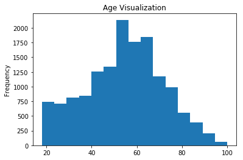

```python
 profile['age'].plot(kind='hist', bins=15, title='Age Visualization')
```

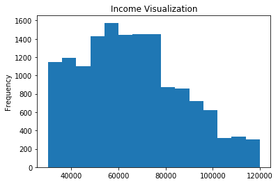

```python
 profile['income'].plot(kind='hist', bins=15, title='Income Visualization')
```

## Transcript dataset understanding and cleaning

```python
transcript.shape
```

```
(306534, 4)
```

```python
transcript.head(30)
```

|  | event | person | time | value |
| --- | --- | --- | --- | --- |
| 0 | offer received | 78afa995795e4d85b5d9ceeca43f5fef | 0 | {'offer id': '9b98b8c7a33c4b65b9aebfe6a799e6d9'} |
| 1 | offer received | a03223e636434f42ac4c3df47e8bac43 | 0 | {'offer id': '0b1e1539f2cc45b7b9fa7c272da2e1d7'} |
| 2 | offer received | e2127556f4f64592b11af22de27a7932 | 0 | {'offer id': '2906b810c7d4411798c6938adc9daaa5'} |
| 3 | offer received | 8ec6ce2a7e7949b1bf142def7d0e0586 | 0 | {'offer id': 'fafdcd668e3743c1bb461111dcafc2a4'} |
| 4 | offer received | 68617ca6246f4fbc85e91a2a49552598 | 0 | {'offer id': '4d5c57ea9a6940dd891ad53e9dbe8da0'} |
| 5 | offer received | 389bc3fa690240e798340f5a15918d5c | 0 | {'offer id': 'f19421c1d4aa40978ebb69ca19b0e20d'} |
| 6 | offer received | c4863c7985cf408faee930f111475da3 | 0 | {'offer id': '2298d6c36e964ae4a3e7e9706d1fb8c2'} |
| 7 | offer received | 2eeac8d8feae4a8cad5a6af0499a211d | 0 | {'offer id': '3f207df678b143eea3cee63160fa8bed'} |
| 8 | offer received | aa4862eba776480b8bb9c68455b8c2e1 | 0 | {'offer id': '0b1e1539f2cc45b7b9fa7c272da2e1d7'} |
| 9 | offer received | 31dda685af34476cad5bc968bdb01c53 | 0 | {'offer id': '0b1e1539f2cc45b7b9fa7c272da2e1d7'} |
| 10 | offer received | 744d603ef08c4f33af5a61c8c7628d1c | 0 | {'offer id': '0b1e1539f2cc45b7b9fa7c272da2e1d7'} |
| 11 | offer received | 3d02345581554e81b7b289ab5e288078 | 0 | {'offer id': '0b1e1539f2cc45b7b9fa7c272da2e1d7'} |
| 12 | offer received | 4b0da7e80e5945209a1fdddfe813dbe0 | 0 | {'offer id': 'ae264e3637204a6fb9bb56bc8210ddfd'} |
| 13 | offer received | c27e0d6ab72c455a8bb66d980963de60 | 0 | {'offer id': '3f207df678b143eea3cee63160fa8bed'} |
| 14 | offer received | d53717f5400c4e84affdaeda9dd926b3 | 0 | {'offer id': '0b1e1539f2cc45b7b9fa7c272da2e1d7'} |
| 15 | offer received | f806632c011441378d4646567f357a21 | 0 | {'offer id': 'fafdcd668e3743c1bb461111dcafc2a4'} |
| 16 | offer received | d058f73bf8674a26a95227db098147b1 | 0 | {'offer id': '0b1e1539f2cc45b7b9fa7c272da2e1d7'} |
| 17 | offer received | 65aba5c617294649aeb624da249e1ee5 | 0 | {'offer id': '2906b810c7d4411798c6938adc9daaa5'} |
| 18 | offer received | ebe7ef46ea6f4963a7dd49f501b26779 | 0 | {'offer id': '9b98b8c7a33c4b65b9aebfe6a799e6d9'} |
| 19 | offer received | 1e9420836d554513ab90eba98552d0a9 | 0 | {'offer id': 'ae264e3637204a6fb9bb56bc8210ddfd'} |
| 20 | offer received | 868317b9be554cb18e50bc68484749a2 | 0 | {'offer id': '2906b810c7d4411798c6938adc9daaa5'} |
| 21 | offer received | f082d80f0aac47a99173ba8ef8fc1909 | 0 | {'offer id': '9b98b8c7a33c4b65b9aebfe6a799e6d9'} |
| 22 | offer received | 102e9454054946fda62242d2e176fdce | 0 | {'offer id': '4d5c57ea9a6940dd891ad53e9dbe8da0'} |
| 23 | offer received | 4beeb3ed64dd4898b0edf2f6b67426d3 | 0 | {'offer id': '2906b810c7d4411798c6938adc9daaa5'} |
| 24 | offer received | 9f30b375d7bd4c62a884ffe7034e09ee | 0 | {'offer id': '2298d6c36e964ae4a3e7e9706d1fb8c2'} |
| 25 | offer received | 25c906289d154b66bf579693f89481c9 | 0 | {'offer id': '2906b810c7d4411798c6938adc9daaa5'} |
| 26 | offer received | 6e014185620b49bd98749f728747572f | 0 | {'offer id': 'f19421c1d4aa40978ebb69ca19b0e20d'} |
| 27 | offer received | 02c083884c7d45b39cc68e1314fec56c | 0 | {'offer id': 'ae264e3637204a6fb9bb56bc8210ddfd'} |
| 28 | offer received | c0d210398dee4a0895b24444a5fcd1d2 | 0 | {'offer id': '9b98b8c7a33c4b65b9aebfe6a799e6d9'} |
| 29 | offer received | 8be4463721e14d7fa600686bf8c8b2ed | 0 | {'offer id': 'fafdcd668e3743c1bb461111dcafc2a4'} |

## extract the offers from transcript dataset

```python
offer = transcript[transcript['value'].apply(lambda x: True if ('offer id' in x) or ('offer_id' in x) else False)]
offer['offer_id'] = offer['value'].apply(lambda x: x['offer id'] if ('offer id' in x) else x['offer_id'])
```

```python
offer.head()
```

|  | event | person | time | value | offer_id |
| --- | --- | --- | --- | --- | --- |
| 0 | offer received | 78afa995795e4d85b5d9ceeca43f5fef | 0 | {'offer id': '9b98b8c7a33c4b65b9aebfe6a799e6d9'} | 9b98b8c7a33c4b65b9aebfe6a799e6d9 |
| 1 | offer received | a03223e636434f42ac4c3df47e8bac43 | 0 | {'offer id': '0b1e1539f2cc45b7b9fa7c272da2e1d7'} | 0b1e1539f2cc45b7b9fa7c272da2e1d7 |
| 2 | offer received | e2127556f4f64592b11af22de27a7932 | 0 | {'offer id': '2906b810c7d4411798c6938adc9daaa5'} | 2906b810c7d4411798c6938adc9daaa5 |
| 3 | offer received | 8ec6ce2a7e7949b1bf142def7d0e0586 | 0 | {'offer id': 'fafdcd668e3743c1bb461111dcafc2a4'} | fafdcd668e3743c1bb461111dcafc2a4 |
| 4 | offer received | 68617ca6246f4fbc85e91a2a49552598 | 0 | {'offer id': '4d5c57ea9a6940dd891ad53e9dbe8da0'} | 4d5c57ea9a6940dd891ad53e9dbe8da0 |

```python
offer.shape
```

```
(167581, 5)
```

Now link the users (person) with the offers to start looking into the demographic for each user and offer

```python
def users_offers(offer, filename, offer_type):

    useroffers = offer.groupby(['person', 'offer_id'])['event'].agg(lambda x: np.nan).unstack()
    if(offer_type == 'bogo'):
        useroffers.drop(list(portfolio[portfolio['offer_type']=='informational']['id']), axis=1, inplace=True)
        useroffers.drop(list(portfolio[portfolio['offer_type']=='discount']['id']), axis=1, inplace=True)
    elif (offer_type == 'discount'):
        useroffers.drop(list(portfolio[portfolio['offer_type']=='informational']['id']), axis=1, inplace=True)
        useroffers.drop(list(portfolio[portfolio['offer_type']=='bogo']['id']), axis=1, inplace=True)
    else:
        useroffers.drop(list(portfolio[portfolio['offer_type']=='discount']['id']), axis=1, inplace=True)
        useroffers.drop(list(portfolio[portfolio['offer_type']=='bogo']['id']), axis=1, inplace=True)

    for offer_id in useroffers.columns:
        num = 0
        for person in useroffers.index:
            num += 1
            if num % 1000 == 0:
                print("OK")
            events = []
            for event in offer[(offer['offer_id']==offer_id) & (offer['person']==person)]['event']:
                events.append(event)
            if len(events) >= 3:
                useroffers.loc[person, offer_id] = 0
                for i in range(len(events)-2):
                    if (events[i] == 'offer received') & (events[i+1] == 'offer viewed') & (events[i+2] == 'offer completed'):
                        useroffers.loc[person, offer_id] += 1
            elif len(events) > 0:
                useroffers.loc[person, offer_id] = 0
    fh = open(filename, 'wb')
    pickle.dump(useroffers,fh)
    fh.close()
    return useroffers
```

```python
Mydataframe_bogo = users_offers(offer, 'useroffers.p','bogo')
```

[output not shown]

[output cut: 9 more lines]

[output not shown]

```python
#Mydataframe_discount = users_offers(offer, 'useroffers_discount.p','discount')
# Furhter work if you need to expand the model
```

[output not shown]

[output cut: 9 more lines]

[output not shown]

```python
#Mydataframe_informational = users_offers(offer, 'useroffers_informational.p','informational')
# Furhter work if you need to expand the model
```

[output not shown]

```python
# Read the new files. to explore them more and try to estimate the best scenario
Mydataframe_bogo.head()
```

| offer_id person | 4d5c57ea9a6940dd891ad53e9dbe8da0 | 9b98b8c7a33c4b65b9aebfe6a799e6d9 | ae264e3637204a6fb9bb56bc8210ddfd | f19421c1d4aa40978ebb69ca19b0e20d |
| --- | --- | --- | --- | --- |
| 0009655768c64bdeb2e877511632db8f | NaN | NaN | NaN | 0.0 |
| 00116118485d4dfda04fdbaba9a87b5c | NaN | NaN | NaN | 0.0 |
| 0011e0d4e6b944f998e987f904e8c1e5 | NaN | 1.0 | NaN | NaN |
| 0020c2b971eb4e9188eac86d93036a77 | 1.0 | NaN | 0.0 | NaN |
| 0020ccbbb6d84e358d3414a3ff76cffd | NaN | 1.0 | NaN | 1.0 |

```python
# Mydataframe_discount.head()   # Furhter work if you need to expand the model
```

```python
#Mydataframe_informational.head()
```

```python
 Mydataframe_bogo.describe
```

[output not shown]

[output cut: 202 more lines]

[output not shown]

## Train and Test the modal to reach to the conclusion and recommendation

We assume the training set size is 75 per cent of the offer dataset and the testing set is 25 per cent

```python
# Import the additional needed libraraies.
# *******-------------- For Data
import seaborn as sns
import warnings
warnings.filterwarnings("ignore")
from sklearn.naive_bayes import GaussianNB
from sklearn.ensemble import AdaBoostClassifier
from sklearn.metrics import accuracy_score,f1_score
from sklearn.model_selection import train_test_split,GridSearchCV
from sklearn.naive_bayes import GaussianNB
from sklearn.neighbors import KNeighborsClassifier
from sklearn.svm import SVC
# *******************************
```

```python
trainingset_size = int(offer.shape[0]*0.75)
testingset_size = offer.shape[0] - trainingset_size
trainingset_size, testingset_size
```

```
(125685, 41896)
```

```python
train_offer = offer[:trainingset_size]
test_offer = offer[trainingset_size:]
train_offer, test_offer
```

[output not shown]

[output cut: 365 more lines]

```python
trainingset_dataframe = users_offers(train_offer, 'trainingset_dataframe.p','bogo')
```

[output not shown]

[output cut: 9 more lines]

[output not shown]

```python
trainingset_dataframe.head()
```

| offer_id person | 4d5c57ea9a6940dd891ad53e9dbe8da0 | 9b98b8c7a33c4b65b9aebfe6a799e6d9 | ae264e3637204a6fb9bb56bc8210ddfd | f19421c1d4aa40978ebb69ca19b0e20d |
| --- | --- | --- | --- | --- |
| 0009655768c64bdeb2e877511632db8f | NaN | NaN | NaN | 0.0 |
| 00116118485d4dfda04fdbaba9a87b5c | NaN | NaN | NaN | 0.0 |
| 0011e0d4e6b944f998e987f904e8c1e5 | NaN | 0.0 | NaN | NaN |
| 0020c2b971eb4e9188eac86d93036a77 | 1.0 | NaN | 0.0 | NaN |
| 0020ccbbb6d84e358d3414a3ff76cffd | NaN | 0.0 | NaN | 1.0 |

```python
testingset_dataframe = users_offers(test_offer, 'testingset_dataframe.p','bogo')
```

[output not shown]

```python
testingset_dataframe.head()
```

| offer_id person | 4d5c57ea9a6940dd891ad53e9dbe8da0 | 9b98b8c7a33c4b65b9aebfe6a799e6d9 | ae264e3637204a6fb9bb56bc8210ddfd | f19421c1d4aa40978ebb69ca19b0e20d |
| --- | --- | --- | --- | --- |
| 0009655768c64bdeb2e877511632db8f | NaN | NaN | NaN | NaN |
| 00116118485d4dfda04fdbaba9a87b5c | NaN | NaN | NaN | 0.0 |
| 0011e0d4e6b944f998e987f904e8c1e5 | NaN | 0.0 | NaN | NaN |
| 0020c2b971eb4e9188eac86d93036a77 | NaN | NaN | NaN | NaN |
| 0020ccbbb6d84e358d3414a3ff76cffd | NaN | 0.0 | NaN | NaN |

```python
# Matrix Factorization Function
def FunkSVD(complete_matrix, latent_features=12, learning_rate=0.0001, iters=75):
    # Complete Offers Matrix
    # Number of features
    # Learnign Rate
    # Iteration
    number_users = complete_matrix.shape[0]
    number_offers = complete_matrix.shape[1]
    num_complete = np.count_nonzero(~np.isnan(complete_matrix))
    user_matrix = np.random.rand(number_users, latent_features)
    offer_matrix = np.random.rand(latent_features, number_offers)
    sum_initialization = 0
    print("Statistics")
    print("Iteration")
    for iteration in range(iters):
        old_sum = sum_initialization
        sum_initialization = 0
        for i in range(number_users):
            for j in range(number_offers):
                if complete_matrix[i, j] >= 0:
                    diff = complete_matrix[i, j] - np.dot(user_matrix[i, :], offer_matrix[:, j])
                    sum_initialization += diff**2
                    for k in range(latent_features):
                        user_matrix[i, k] += learning_rate * (2*diff*offer_matrix[k, j])
                        offer_matrix[k, j] += learning_rate * (2*diff*user_matrix[i, k])
        print("%d \t\t %f" % (iteration+1, sum_initialization / num_complete))
    return user_matrix, offer_matrix
```

```python
train_data_np = np.array(trainingset_dataframe)
user_matrix, offer_matrix = FunkSVD(train_data_np, latent_features=15, learning_rate=0.005, iters=150)
```

```
Statistics
Iteration
1 		 0.318031
2 		 0.266795
3 		 0.266565
4 		 0.266333
5 		 0.266098
6 		 0.265860
7 		 0.265619
8 		 0.265375
9 		 0.265127
10 		 0.264876
11 		 0.264622
12 		 0.264363
13 		 0.264099
```

[output cut: 137 more lines]

```python
user_mat_10, offer_mat_10 = FunkSVD(train_data_np, latent_features=10, learning_rate=0.005, iters=150)
```

```
Statistics
Iteration
1 		 0.299500
2 		 0.265515
3 		 0.265223
4 		 0.264928
5 		 0.264631
6 		 0.264332
7 		 0.264032
8 		 0.263729
9 		 0.263424
10 		 0.263117
11 		 0.262808
12 		 0.262496
13 		 0.262182
```

[output cut: 137 more lines]

```python
def prediction(user_matrix, offer_matrix, user_id, offer_id):
    try:
        user_ids_series = np.array(trainingset_dataframe.index)
        offer_ids_series = np.array(trainingset_dataframe.columns)
        user_row = np.where(user_ids_series == user_id)[0][0]
        offer_col = np.where(offer_ids_series == offer_id)[0][0]
        pred = np.dot(user_matrix[user_row, :], offer_matrix[:, offer_col])
        return pred
    except:
        return None
```

```python
def validation(testingset_dataframe, user_matrix, offer_matrix):
    num_complete = np.count_nonzero(~np.isnan(testingset_dataframe))
    sum_initialization = 0
    for user_id in testingset_dataframe.index:
        for offer_id in testingset_dataframe.columns:
            if ~np.isnan(testingset_dataframe.loc[user_id, offer_id]):
                predict_value = prediction(user_matrix, offer_matrix, user_id, offer_id)
                if predict_value != None:
                    diff = testingset_dataframe.loc[user_id, offer_id] - prediction(user_matrix, offer_matrix, user_id, offer_id)
                    sum_initialization += diff**2
    print(sum_initialization / num_complete)
```

```python
validation(testingset_dataframe, user_matrix, offer_matrix)
```

```
0.282142859377
```

```python
validation(testingset_dataframe, user_mat_10, offer_mat_10)
```

```
0.274481812438
```

```python
def recommendation(user_id, user_matrix, offer_matrix):
    recommend = {}
    for offer_id in trainingset_dataframe.columns:
        pred_val = prediction(user_matrix, offer_matrix, user_id, offer_id)
        if pred_val != None:
            recommend[offer_id] = pred_val
        else:
            break
    if pred_val == None:
        print("the user is not in the database, so we assume that he will acept the offer")
        top_offer = best_sale_offer(full_df)
        for offer_id in top_offer['offer_id']:
            print("offer id: ", offer_id)
    else:
        print("The recommended offer for user ", user_id)
        for offer_id, pred_val in sorted(recommend.items(), key=lambda kv:(kv[1], kv[0]), reverse=True):
            print("offer id: ", offer_id, " predicted value: ", round(pred_val,2))
```

```python
recommendation('8ec6ce2a7e7949b1bf142def7d0e0586', user_matrix, offer_matrix)
```

```
The recommended offer for user  8ec6ce2a7e7949b1bf142def7d0e0586
offer id:  f19421c1d4aa40978ebb69ca19b0e20d  predicted value:  0.26
offer id:  9b98b8c7a33c4b65b9aebfe6a799e6d9  predicted value:  0.23
offer id:  4d5c57ea9a6940dd891ad53e9dbe8da0  predicted value:  0.14
offer id:  ae264e3637204a6fb9bb56bc8210ddfd  predicted value:  -0.48
```